# Draft Prediction Interval

## Model Validation

Now we predict at validation sites.

```r
fitmodel_gstat <- as.vgm.variomodel(lmm.exp)
coordinates(valid) <- ~x + y
coordinates(calib) <- ~x + y
eblup <- krige(clay~lu+pc5+pc6,
               calib,valid,model = fitmodel_gstat,debug.level=-1)
```

```
## [using universal kriging]
##
100% done
```

```r
summary(eblup$var1.pred)
```

```
##    Min. 1st Qu.  Median    Mean 3rd Qu.    Max.
##   12.73   24.43   34.47   34.99   46.52   55.63
```

## Test Point Estimates

```r
mean(eblup$var1.pred-valid$clay)
```

```
## [1] -6.681346
```

```r
sqrt(mean((eblup$var1.pred-valid$clay)^2))
```

```
## [1] 16.43896
```

### Plot data

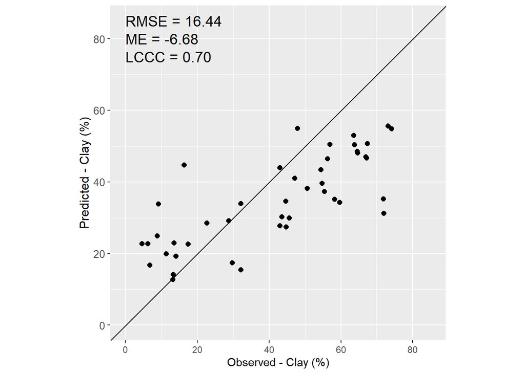

```r
plot.df<-cbind(valid$clay,eblup$var1.pred)
plot.df<-as.data.frame(plot.df)
colnames(plot.df)[1] <- "observed"
colnames(plot.df)[2] <- "predicted"

sum.df<-data.frame (
  stats=c("RMSE = 16.44","ME = -6.68", "LCCC = 0.70"),
  y=c(85.0, 80.0, 75.0))

#tiff('calib_lmm.tiff')
ggplot(plot.df, aes(x = observed, y = predicted)) +
  geom_point(size=2) +
  xlab("Observed - Clay (%)") +
  ylab("Predicted - Clay (%)") +
  theme(axis.title.y = element_text(size=12),axis.text.y  = element_text(size=10))+
  xlim(0,85)+
  ylim(0,85)+
  geom_abline(intercept = 0, slope = 1) +
  coord_equal()+
  geom_text(data=sum.df,aes(x=0,y=y,label=stats),size=5, hjust=0)
```

```r
#dev.off()
```

## Test Interval Estimates

```r
valid.df<-data.frame(valid,eblup$var1.pred,eblup$var1.var)
valid.df$ID<-seq(1,44,1)
```

95% interval

```r
sum.df<-data.frame (
  stats=c("Coverage Probability = 0.88"),
  y=c(-10))

PIl95<-valid.df$eblup.var1.pred-sqrt(valid.df$eblup.var1.var)*1.96
PIu95<-valid.df$eblup.var1.pred+sqrt(valid.df$eblup.var1.var)*1.96

valid.df$hit95<-as.numeric(valid.df$clay >= PIl95 & valid.df$clay <= PIu95)
hit95<-sum(valid.df$hit95)/44
hit95
```

```
## [1] 0.8863636
```

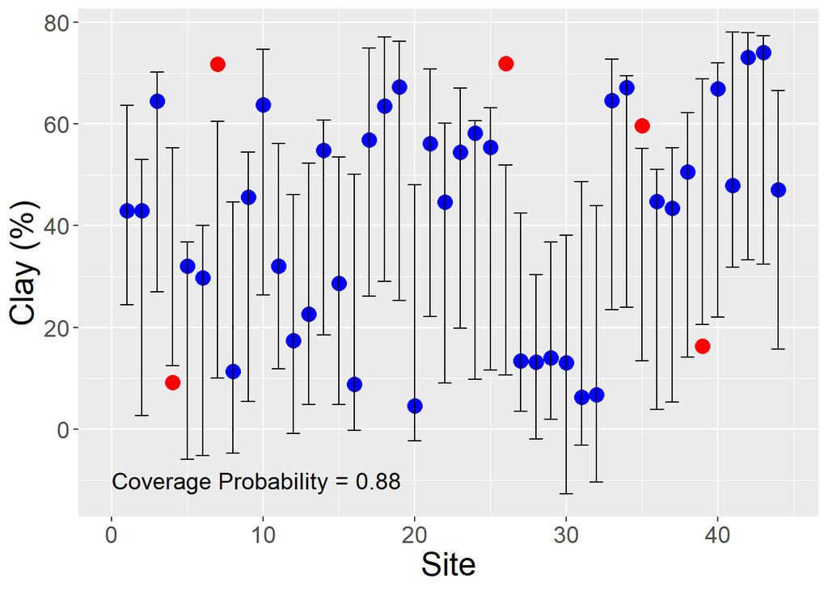

```r
ggplot(valid.df, aes(x = ID, y = clay)) +
  geom_point(data=valid.df[which(valid.df$hit95==1),],colour='blue',size=4) +
  geom_point(data=valid.df[which(valid.df$hit95==0),],colour='red',size=4) +
  #geom_point(size = 4) +
  ylab("Clay (%)") +
  xlab("Site") +
  #theme(axis.title.y = element_text(size=20))+
  theme(axis.title.y = element_text(size=20),axis.text.y  = element_text(size=14))+
  theme(axis.title.x = element_text(size=20),axis.text.x  = element_text(size=14))+
  geom_errorbar(aes(ymax = PIu95, ymin = PIl95))+
  geom_text(data=sum.df,aes(x=0,y=y,label=stats),size=5, hjust=0)
```

90% interval

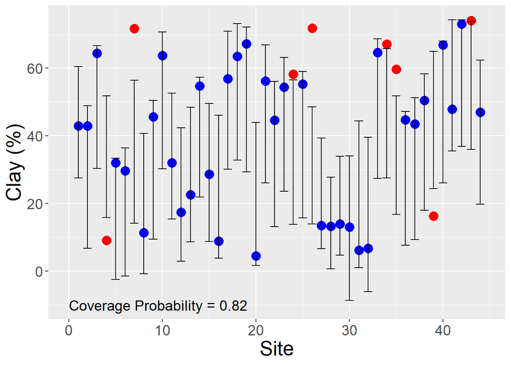

```r
sum.df<-data.frame (
  stats=c("Coverage Probability = 0.82"),
  y=c(-10))

PIl95<-valid.df$eblup.var1.pred-sqrt(valid.df$eblup.var1.var)*1.645
PIu95<-valid.df$eblup.var1.pred+sqrt(valid.df$eblup.var1.var)*1.645

valid.df$hit90<-as.numeric(valid.df$clay >= PIl95 & valid.df$clay <= PIu95)
hit90<-sum(valid.df$hit90)/44
ggplot(valid.df, aes(x = ID, y = clay)) +
  geom_point(data=valid.df[which(valid.df$hit90==1),],colour='blue',size=4) +
  geom_point(data=valid.df[which(valid.df$hit90==0),],colour='red',size=4) +
  #geom_point(size = 4) +
  ylab("Clay (%)") +
  xlab("Site") +
  #theme(axis.title.y = element_text(size=20))+
  theme(axis.title.y = element_text(size=20),axis.text.y  = element_text(size=14))+
  theme(axis.title.x = element_text(size=20),axis.text.x  = element_text(size=14))+
  geom_errorbar(aes(ymax = PIu95, ymin = PIl95))+
  geom_text(data=sum.df,aes(x=0,y=y,label=stats),size=5, hjust=0)
```

66% interval

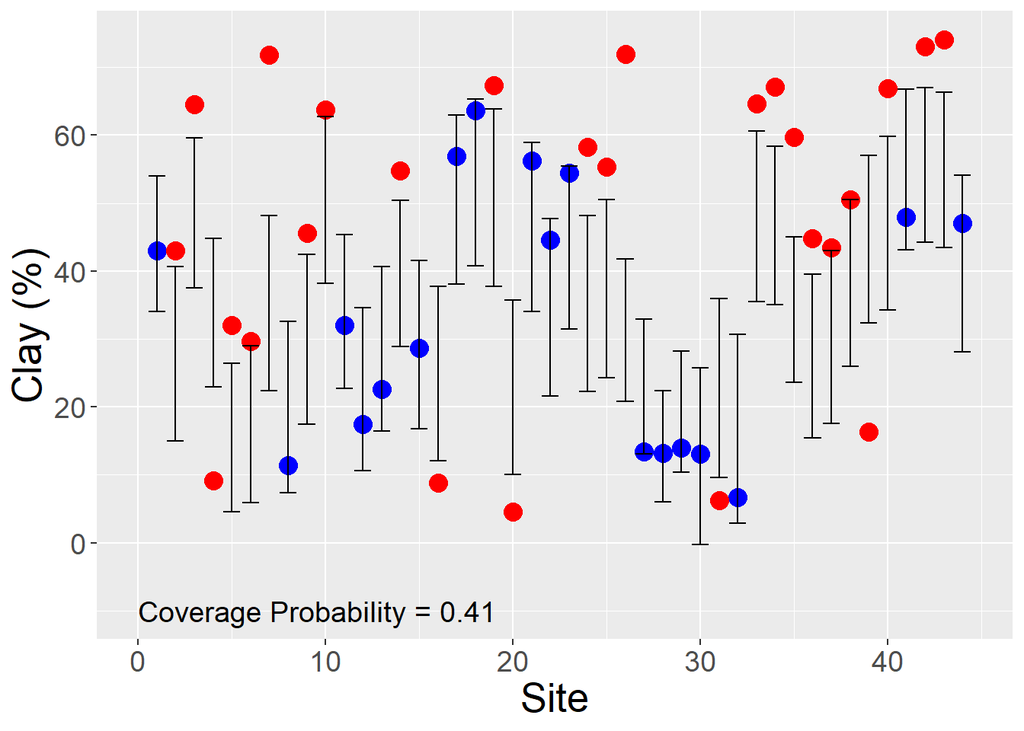

```r
sum.df<-data.frame (
  stats=c("Coverage Probability = 0.41"),
  y=c(-10))

PIl95<-valid.df$eblup.var1.pred-sqrt(valid.df$eblup.var1.var)*1
PIu95<-valid.df$eblup.var1.pred+sqrt(valid.df$eblup.var1.var)*1

valid.df$hit66<-as.numeric(valid.df$clay >= PIl95 & valid.df$clay <= PIu95)
hit66<-sum(valid.df$hit66)/44
ggplot(valid.df, aes(x = ID, y = clay)) +
  geom_point(data=valid.df[which(valid.df$hit66==1),],colour='blue',size=4) +
  geom_point(data=valid.df[which(valid.df$hit66==0),],colour='red',size=4) +
  #geom_point(size = 4) +
  ylab("Clay (%)") +
  xlab("Site") +
  #theme(axis.title.y = element_text(size=20))+
  theme(axis.title.y = element_text(size=20),axis.text.y  = element_text(size=14))+
  theme(axis.title.x = element_text(size=20),axis.text.x  = element_text(size=14))+
  geom_errorbar(aes(ymax = PIu95, ymin = PIl95))+
  geom_text(data=sum.df,aes(x=0,y=y,label=stats),size=5, hjust=0)
```

In talk had 95, 90, 80, 50, 20% PI - could do this.

Could plot covergage probability versus PI

# Random Forest Modelling

```r
rf_model <- randomForest(clay ~ soil+lu+pc1+pc2+pc3+pc4+pc5+pc6,data=calib, ntree = 500, mtry = 3,importance = TRUE,do.trace = 100, proximity=TRUE)
```

```
##      |      Out-of-bag   |
## Tree |      MSE  %Var(y) |
##  100 |    144.1    53.60 |
##  200 |    136.3    50.71 |
##  300 |    133.2    49.56 |
##  400 |    134.3    49.94 |
##  500 |    134.3    49.94 |
```

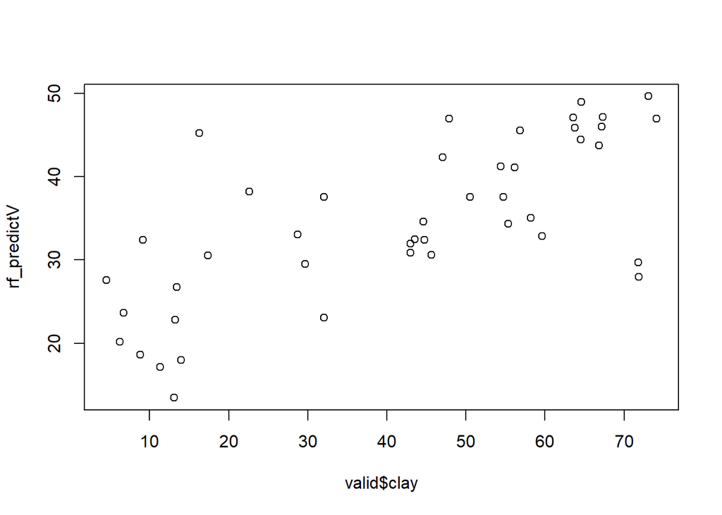

```r
rf_predictV<-predict(rf_model, valid)
plot(valid$clay,rf_predictV)
```

```r
mean(rf_predictV-valid$clay)
```

```
## [1] -7.068795
```

```r
sqrt(mean((rf_predictV-valid$clay)^2))
```

```
## [1] 18.17764
```

Extract individual trees

```r
rf_predictVi<-predict(rf_model, valid,predict.all=TRUE)
individual=rf_predictVi$individual #extract the matrix where each column contains the predictions by each tree in the forest
aggregate=rf_predictVi$aggregate  #mean of trees
```

Extract parts of tree

```r
aggregate=rf_predictVi$aggregate  #extract the average of predictions
agg1=aggregate[[1]]   #extract the average for a specific position
```

extract the entire Mth row corresponding to all the predictions for that position in the tree extract quantiles for validation points

```r
output<-data.frame(NA,ncol=12,nrow=length(individual[,1]))

kount<-0

for (i in 1:length(individual[,1])){

  ind1=individual[i,]

  qu<-quantile(ind1, probs=c(0.025,0.05,0.1,0.25,0.4,0.5,0.6,0.75,0.9,0.95,0.975))
  ave<-mean(ind1)

  kount<-kount+1

  output[kount,1]<-qu[1]
  output[kount,2]<-qu[2]
  output[kount,3]<-qu[3]
  output[kount,4]<-qu[4]
  output[kount,5]<-qu[5]
  output[kount,6]<-qu[6]
  output[kount,7]<-qu[7]
  output[kount,8]<-qu[8]
  output[kount,9]<-qu[9]
  output[kount,10]<-qu[10]
  output[kount,11]<-qu[11]
  output[kount,12]<-ave

  print(kount)
}
```

[output not shown]

[output cut: 29 more lines]

```r
qout<-output

names(qout)[1:12] <- c("q2.5","q5","q10","q25","q40","q50","q60","q75","q90","q95","q97.5","ave")

head(qout)
```

```
##        q2.5        q5       q10       q25      q40      q50      q60      q75
## 1  6.403911  6.813070  8.015370 15.540652 25.51822 33.70123 40.73900 47.01660
## 2 10.041692 13.861707 17.681012 25.590654 29.65493 31.68757 32.60273 34.43552
## 3 10.209944 24.443676 30.717943 36.009526 44.20312 47.27564 50.21485 52.35872
## 4  5.478254  6.217775  7.405595 14.118200 33.39851 40.79491 42.54998 44.79655
## 5  4.415795  5.388770  6.330716  8.346535 15.25980 19.66480 25.22008 34.30990
## 6  7.481380  8.983625 11.507100 21.547051 28.95682 31.66345 32.70127 34.23543
##        q90      q95    q97.5      ave
## 1 52.24485 54.60316 58.85474 31.93208
## 2 44.42937 48.28996 51.79650 30.83736
## 3 56.01966 60.34450 67.58417 44.42410
## 4 50.19003 52.01609 55.11383 32.38222
## 5 44.55110 48.31393 56.01966 23.07265
## 6 45.88936 50.57788 54.18811 29.52126
```

```r
id<-1:44

qout<-cbind(id,valid$clay,qout)

names(qout)[1:2] <- c("Site","Clay")
```

#95% PI #Calculate hits

```r
qout$hit95<-as.numeric(qout$Clay >= qout$q2.5 & qout$Clay <= qout$q97.5)
sum(qout$hit95)/44
```

```
## [1] 0.75
```

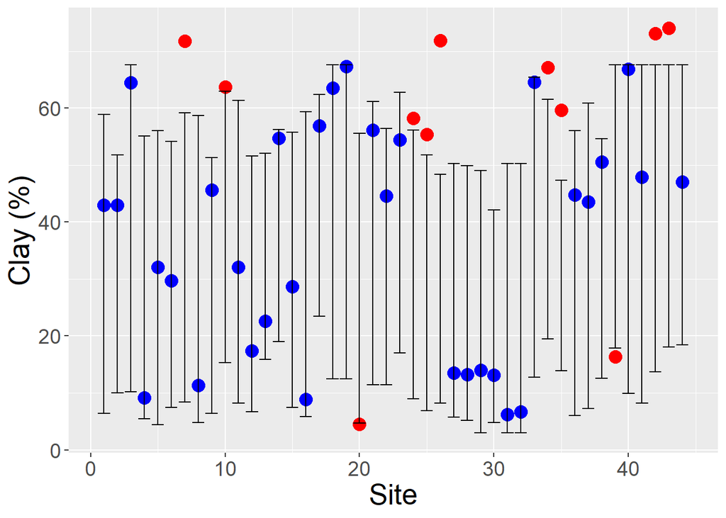

```r
ggplot(qout, aes(x = Site, y = Clay)) +
  geom_point(data=qout[which(qout$hit95==1),],colour='blue',size=4) +
  geom_point(data=qout[which(qout$hit95==0),],colour='red',size=4) +
  #geom_point(size = 4) +
  ylab("Clay (%)") +
  xlab("Site") +
  #theme(axis.title.y = element_text(size=20))+
  theme(axis.title.y = element_text(size=20),axis.text.y  = element_text(size=14))+
  theme(axis.title.x = element_text(size=20),axis.text.x  = element_text(size=14))+
  geom_errorbar(aes(ymax = q97.5, ymin = q2.5))
```

Put in set.seed to get same RF split

Save workspace

```r
save.image("paper.RMD")
```